# Seurat: Spatial dataset

This tutorial demonstrates how to use Seurat (>=3.2) to analyze spatially-resolved RNA-seq data. While the analytical pipelines are similar to the Seurat workflow for single-cell RNA-seq analysis, we introduce updated interaction and visualization tools, with a particular emphasis on the integration of spatial and molecular information. This tutorial will cover the following tasks, which we believe will be common for many spatial analyses:

- Normalization
- Dimensionality reduction and clustering
- Detecting spatially-variable features
- Interactive visualization
- Integration with single-cell RNA-seq data
- Working with multiple slices

For our first vignette, we analyze a dataset generated with the Visium technology from 10x Genomics. We will be extending Seurat to work with additional data types in the near-future, including SLIDE-Seq, STARmap, and MERFISH.

First, we load Seurat and the other packages necessary for this vignette.

```r
library(Seurat)
library(SeuratData)
```

```
-- Installed datasets ------------------------------------- SeuratData v0.2.1 --

-------------------------------------- Key -------------------------------------
v Dataset loaded successfully
> Dataset built with a newer version of Seurat than installed
(?) Unknown version of Seurat installed
```

```r
library(ggplot2)
library(patchwork)
library(dplyr)
```

## Dataset

```r
# InstallData("stxBrain")
```

```r
brain <- LoadData("stxBrain", type = "anterior1")
```

The visium data from 10x consists of the following data types: * A spot by gene expression matrix * An image of the tissue slice (obtained from H&E staining during data acquisition) * Scaling factors that relate the original high resolution image to the lower resolution image used here for visualization.

In the Seurat object, the spot by gene expression matrix is similar to a typical “RNA” `Assay` but contains spot level, not single-cell level data. The image itself is stored in a new `images` slot in the Seurat object. The `images` slot also stores the information necessary to associate spots with their physical position on the tissue image.

## Data preprocessing

The initial preprocessing steps that we perform on the spot by gene expression data are similar to a typical scRNA-seq experiment. We first need to normalize the data in order to account for variance in sequencing depth across data points. We note that the variance in molecular counts / spot can be substantial for spatial datasets, particularly if there are differences in cell density across the tissue. We see substantial heterogeneity here, which requires effective normalization.

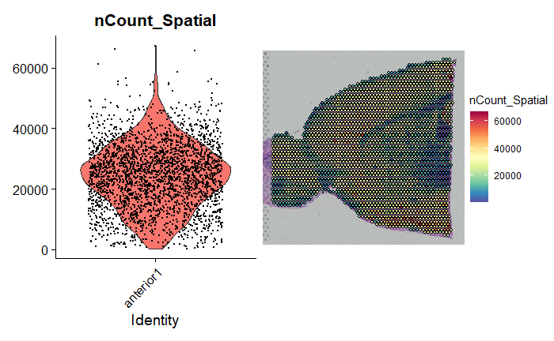

```r
plot1 <- VlnPlot(brain, features = "nCount_Spatial", pt.size = 0.1) + NoLegend()
plot2 <- SpatialFeaturePlot(brain, features = "nCount_Spatial") + theme(legend.position = "right")
wrap_plots(plot1, plot2)
```

These plots demonstrate that the variance in molecular counts across spots is not just technical in nature, but also is dependent on the tissue anatomy. For example, regions of the tissue that are depleted for neurons (such as the cortical white matter), reproducibly exhibit lower molecular counts. As a result, standard approaches (such as the LogNormalize function), which force each data point to have the same underlying ‘size’ after normalization, can be problematic.

As an alternative, we recommend using `sctransform`, which builds regularized negative binomial models of gene expression in order to account for technical artifacts while preserving biological variance. `sctransform` normalizes the data, detects high-variance features, and stores the data in the `SCT` assay.

```r
brain <- SCTransform(brain, assay = "Spatial", verbose = FALSE)
```

[output not shown]

[output not shown]

[output not shown]

[output not shown]

[output not shown]

[output not shown]

[output not shown]

[output not shown]

## Gene expression visualization

The `SpatialFeaturePlot` function in Seurat extends `FeaturePlot`, and can overlay molecular data on top of tissue histology. For example, in this dataset of the mouse brain, the gene Hpca is a strong hippocampal marker and Ttr is a marker of the choroid plexus.

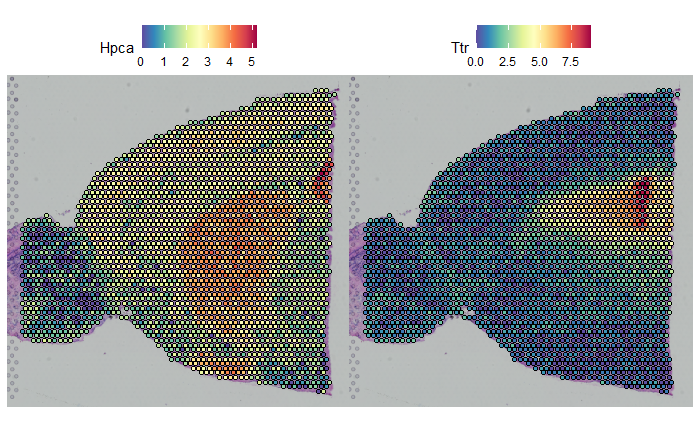

```r
SpatialFeaturePlot(brain, features = c("Hpca", "Ttr"))
```

The default parameters in Seurat emphasize the visualization of molecular data. However, you can also adjust the size of the spots (and their transparency) to improve the visualization of the histology image, by changing the following parameters:

- pt.size.factor- This will scale the size of the spots. Default is 1.6
- alpha - minimum and maximum transparency. Default is c(1, 1).

Try setting to alpha c(0.1, 1), to downweight the transparency of points with lower expression

## Dimensionality reduction, clustering, and visualization

We can then proceed to run dimensionality reduction and clustering on the RNA expression data, using the same workflow as we use for scRNA-seq analysis.

```r
brain <- RunPCA(brain, assay = "SCT", verbose = FALSE)
brain <- FindNeighbors(brain, reduction = "pca", dims = 1:30)
brain <- FindClusters(brain, verbose = FALSE)
brain <- RunUMAP(brain, reduction = "pca", dims = 1:30)
```

```
The default method for RunUMAP has changed from calling Python UMAP via reticulate to the R-native UWOT using the cosine metric
To use Python UMAP via reticulate, set umap.method to 'umap-learn' and metric to 'correlation'
This message will be shown once per session12:03:54 UMAP embedding parameters a = 0.9922 b = 1.112
```

We can then visualize the results of the clustering either in UMAP space (with `DimPlot`) or overlayed on the image with `SpatialDimPlot.`

```r
p1 <- DimPlot(brain, reduction = "umap", label = TRUE)
```

```
Using `as.character()` on a quosure is deprecated as of rlang 0.3.0.
Please use `as_label()` or `as_name()` instead.
```

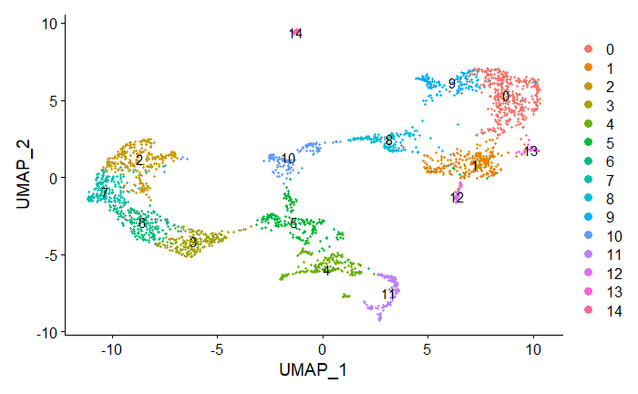

```r
p2 <- SpatialDimPlot(brain, label = TRUE, label.size = 3)
p1
```

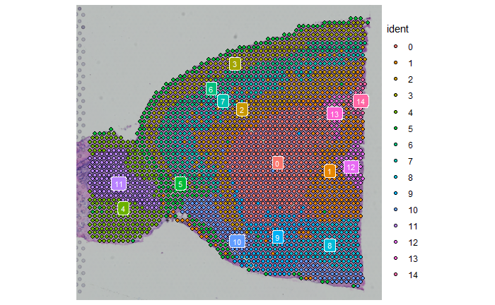

```r
p2
```

As there are many colors, it can be challenging to visualize which voxel belongs to which cluster. We have a few strategies to help with this. Setting the `label` parameter places a colored box at the median of each cluster (see the plot above).

You can also use the `cells.highlight` parameter to demarcate particular cells of interest on a `SpatialDimPlot.` This can be very useful for distinguishing the spatial localization of individual clusters, as we show below:

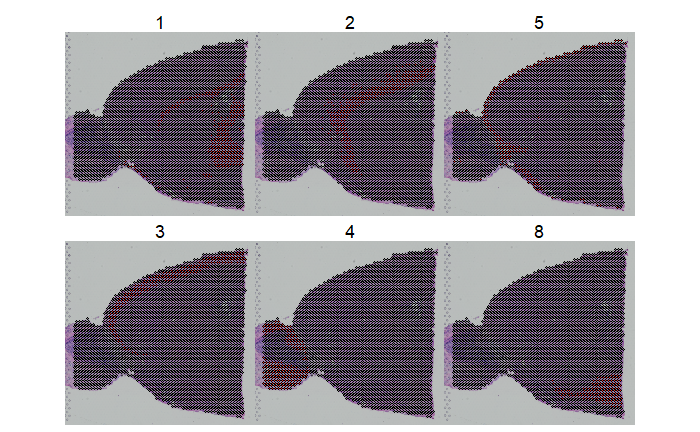

```r
SpatialDimPlot(brain, cells.highlight = CellsByIdentities(object = brain, idents = c(1, 2, 5, 3,
    4, 8)), facet.highlight = TRUE, ncol = 3)
```

## Identification of Spatially Variable Features

Seurat offers two workflows to identify molecular features that correlate with spatial location within a tissue. The first is to perform differential expression based on pre-annotated anatomical regions within the tissue, which may be determined either from unsupervised clustering or prior knowledge. This strategy works will in this case, as the clusters above exhibit clear spatial restriction.

```r
de_markers <- FindMarkers(brain, ident.1 = 4, ident.2 = 6)
```

[output not shown]

[output cut: 43 more lines]

[output not shown]

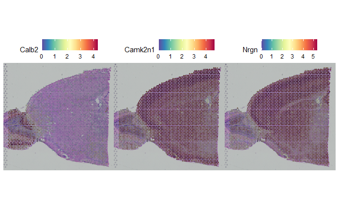

```r
SpatialFeaturePlot(object = brain, features = rownames(de_markers)[1:3], alpha = c(0.1, 1), ncol = 3)
```

An alternative approach, implemented in `FindSpatiallyVariables`, is to search for features exhibiting spatial patterning in the absence of pre-annotation. The default method (method = ‘markvariogram’), is inspired by the Trendsceek, which models spatial transcriptomics data as a mark point process and computes a ‘variogram’, which identifies genes whose expression level is dependent on their spatial location. More specifically, this process calculates gamma(r) values measuring the dependence between two spots a certain “r” distance apart. By default, we use an r-value of ‘5’ in these analyes, and only compute these values for variable genes (where variation is calculated independently of spatial location) to save time.

We note that there are mulitple methods in the literature to accomplish this task, including SpatialDE, and Splotch. We encourage interested users to explore these methods, and hope to add support for them in the near future.

```r
# brain <- FindSpatiallyVariableFeatures(brain, assay = "SCT", features = VariableFeatures(brain)[1:1000],
#    selection.method = "markvariogram")
```

```r
# top.features <- head(SpatiallyVariableFeatures(brain, selection.method = "markvariogram"), 6)
#  SpatialFeaturePlot(brain, features = top.features, ncol = 3, alpha = c(0.1, 1))
```

## Subset out anatomical regions

```r
cortex <- subset(brain, idents = c(1, 2, 3, 5, 6, 7))
```

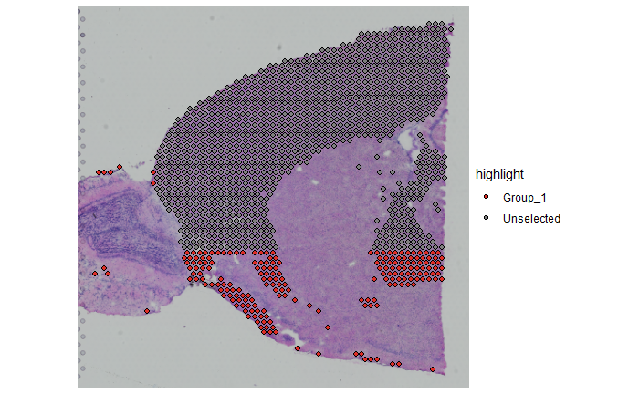

```r
# now remove additional cells, use SpatialDimPlots to visualize what to remove
SpatialDimPlot(cortex,cells.highlight = WhichCells(cortex, expression = anterior1_imagerow > 400 |
anterior1_imagecol < 150))
```

```r
cortex <- subset(cortex, anterior1_imagerow > 400 | anterior1_imagecol < 150, invert = TRUE)
cortex <- subset(cortex, anterior1_imagerow > 275 & anterior1_imagecol > 370, invert = TRUE)
cortex <- subset(cortex, anterior1_imagerow > 250 & anterior1_imagecol > 440, invert = TRUE)

# After subsetting, we renormalize cortex
cortex <- SCTransform(cortex, assay = "Spatial", verbose = FALSE) %>% RunPCA(verbose = FALSE)
```

## Integration with single-cell data

We apply the ‘anchor’-based integration workflow recently introduced in Seurat v3, that enables the probabilistic transfer of annotations from a reference to a query set. We therefore follow the label transfer workflow introduced here, taking advantage of sctransform normalization, but anticipate new methods to be developed to accomplish this task.

We first load the data, pre-process the scRNA-seq reference, and then perform label transfer. The procedure outputs, for each spot, a probabilistic classification for each of the scRNA-seq derived classes. We add these predictions as a new assay in the Seurat object.

```r
allen_reference <- readRDS("../rds/allen_cortex.rds")
```

```r
# note that setting ncells=3000 normalizes the full dataset but learns noise models on 3k cells
# this speeds up SCTransform dramatically with no loss in performance
allen_reference <- SCTransform(allen_reference, ncells = 3000, verbose = FALSE) %>% RunPCA(verbose = FALSE) %>%
    RunUMAP(dims = 1:30)
```

[output not shown]

[output not shown]

[output not shown]

[output not shown]

[output not shown]

[output not shown]

[output not shown]

[output not shown]

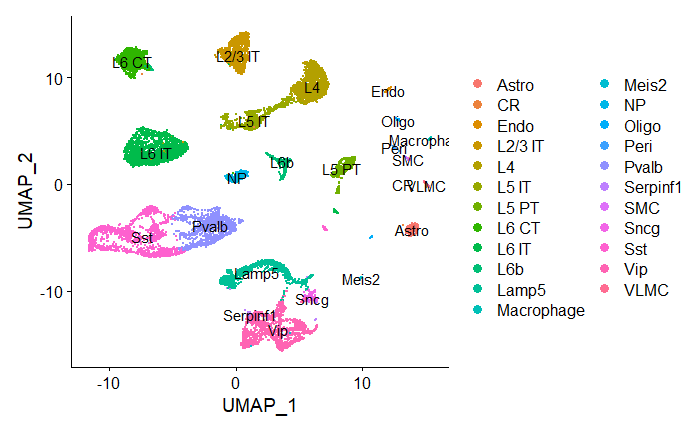

```r
# the annotation is stored in the 'subclass' column of object metadata
DimPlot(allen_reference, group.by = "subclass", label = TRUE)
```

```r
anchors <- FindTransferAnchors(reference = allen_reference, query = cortex, normalization.method = "SCT")
```

```
Performing PCA on the provided reference using 2008 features as input.
Projecting PCA
Finding neighborhoods
Finding anchors
    Found 1241 anchors
Filtering anchors
    Retained 1236 anchors
```

```r
predictions.assay <- TransferData(anchorset = anchors, refdata = allen_reference$subclass, prediction.assay = TRUE,
    weight.reduction = cortex[["pca"]])
```

```
Finding integration vectors
Finding integration vector weights
Predicting cell labels
```

```r
cortex[["predictions"]] <- predictions.assay
```

Now we get prediction scores for each spot for each class. Of particular interest in the frontal cortex region are the laminar excitatory neurons. Here we can distinguish between distinct sequential layers of these neuronal subtypes, for example:

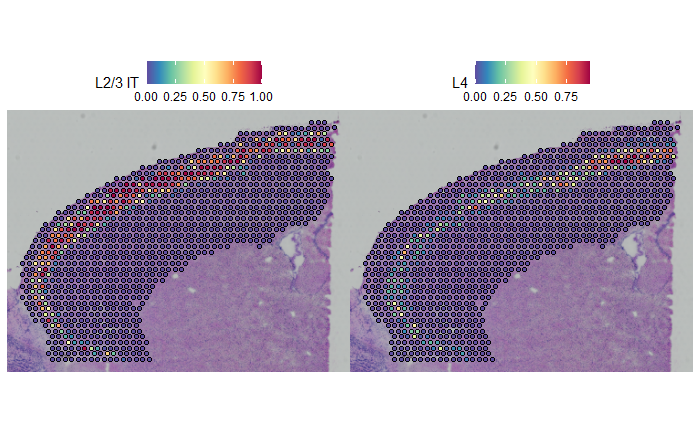

```r
DefaultAssay(cortex) <- "predictions"
SpatialFeaturePlot(cortex, features = c("L2/3 IT", "L4"), pt.size.factor = 1.6, ncol = 2, crop = TRUE)
```

Based on these prediction scores, we can also predict cell types whose location is spatially restricted. We use the same methods based on marked point processes to define spatially variable features, but use the cell type prediction scores as the “marks” rather than gene expression.

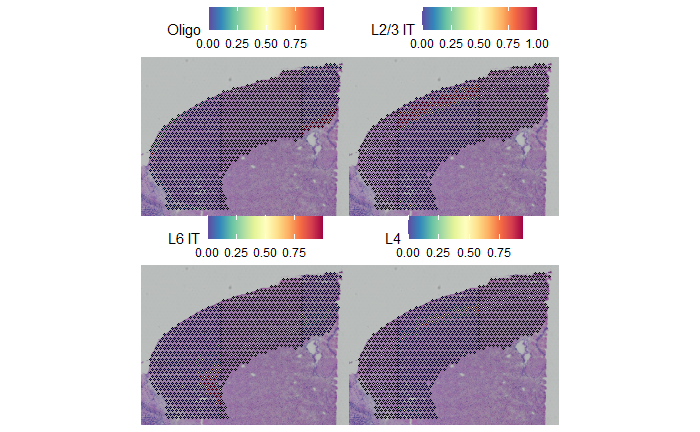

```r
cortex <- FindSpatiallyVariableFeatures(cortex, assay = "predictions", selection.method = "markvariogram",
    features = rownames(cortex), r.metric = 5, slot = "data")
top.clusters <- head(SpatiallyVariableFeatures(cortex), 4)
SpatialPlot(object = cortex, features = top.clusters, ncol = 2)
```

```r
saveRDS(brain, file = "../rds/brain.rds")
saveRDS(brain, file = "../rds/cortex.rds")
```